# Coursera Capstone Project - A natural language processing model (NLP) with 'ngram' continuation probabilities via Kneser-Ney smoothing.

Mark A. Jack; November 24, 2016.

### Text corpus, package 'quanteda' and ngrams

- Three data files from a 'blogs', 'twitter' and 'news' feed are combined to a text corpus using the 'tm' package.
- Via libary 'quanteda', the corpus is tokenized and text features such as punctuation, numbers, white space, lowercase words etc. are removed.
- 'ngrams' - unigrams, bigrams, trigrams and quadgrams - are generated via a document-frequency matrix (dfm).
- A 'dfm' allows for quick and easy analysis of the most frequently occurying ngrams.

### Most frequently occurring ngrams

We show the number of occurances of each of the most common unigrams and bigrams in horizontal bar plots.

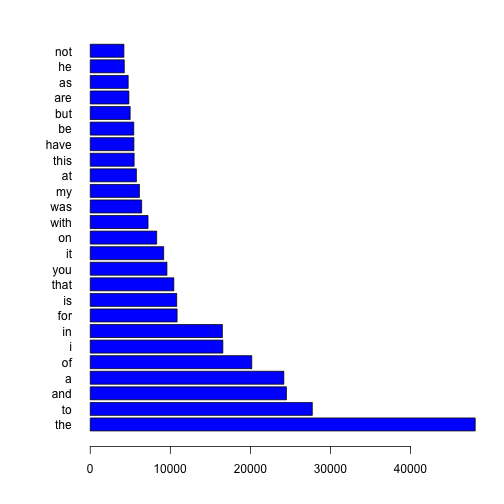

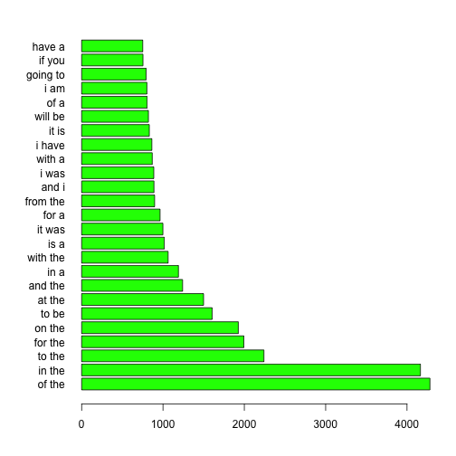

#### Figure 1. Unigram and bigram occurences in descending order.

### Trigram and quadgram occurrences

For unigrams, bigrams, and trigrams, 1% of the selected text corpus was used. The sample for the quadgrams was restricted to 0.1% of the corpus due to memory limitations.

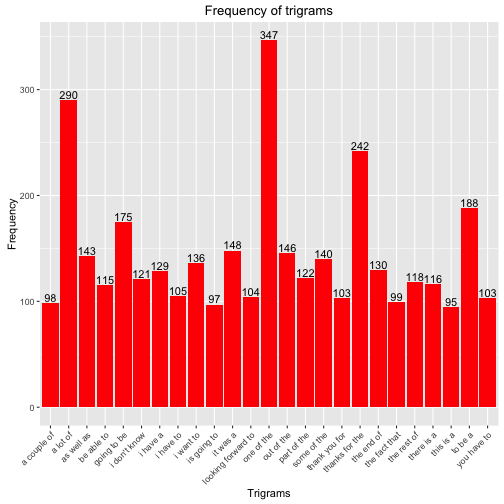

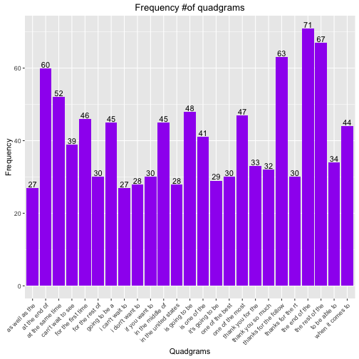

#### Figure 2. Trigram and quadgram occurrences, alphabetically sorted.

### Continuation probabilities, Kneser-Ney smoothing and shiny app

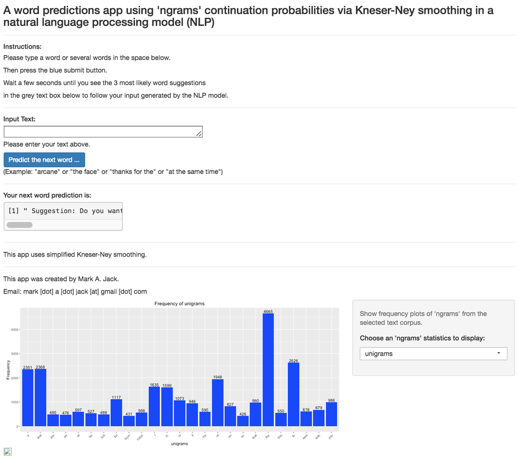

- Continuation probability of each unigram estimated from bigram occurrences that continue a unigram etc.
- Probabilities are corrected via Kneser-Ney smoothing by 'estimating' the likelihood of 'ngrams' missing in the corpus.